# SDS/CSC 293 Mini-Project 2: Multiple Regression

Group 11: Nashshaba Nawaz & Cassidy Maher

Wednesday, March 6<sup>th</sup>, 2019

You will be submiting an entry to Kaggle’s [House Prices: Advanced Regression Techniques](https://www.kaggle.com/c/house-prices-advanced-regression-techniques/) by fitting a **multiple regression** model $\hat{f}(x)$.

# EDA

Read in data provided by Kaggle for this competition. They are organized in the `data/` folder of this RStudio project:

```r
training <- read_csv("data/train.csv")
test <- read_csv("data/test.csv")
sample_submission <- read_csv("data/sample_submission.csv")
```

## Data wrangling

As much as possible, try to do all your data wrangling here:

```r
# Do a log10 xform on sale price to prevent negative price predictions later on
training <- training %>%
  mutate(log10_SalePrice = log10(SalePrice),
         log10_GrLivArea = log10(GrLivArea),
         MSSubClass = as.factor(MSSubClass))
test <- test %>%
  mutate(log10_GrLivArea = log10(GrLivArea),
         MSSubClass = as.factor(MSSubClass))

# Convert all character variables to factors
training <- training %>% mutate_if(is.character, as.factor)
test <- test %>% mutate_if(is.character, as.factor)
```

## Visualizations

We examined the relationships between the outcome variable and the predictors of each model while determining which variables would be good to use in the model. Though we will not include those visualizations here, it is important to note that we looked at them while determining what best predictor variables might be available for the strongest relationships with our outcome variable.

```r
plot1 <- ggplot(training, aes(x = log10_GrLivArea, y = log10_SalePrice)) +
  geom_point() +
  labs(x = "log10(Above ground living area in square feet)",
       y = "log10(Sale price in USD)",
       title = "SalePrice against GrLivArea")
```

```r
plot2 <- ggplot(training, aes(x = HouseStyle, y = log10_SalePrice)) +
  geom_boxplot(fill =  "darkolivegreen1") +
  labs(x = "Style of Dwelling",
       y = "log10(Sale price in USD)",
       title = "SalePrice against HouseStyle")
```

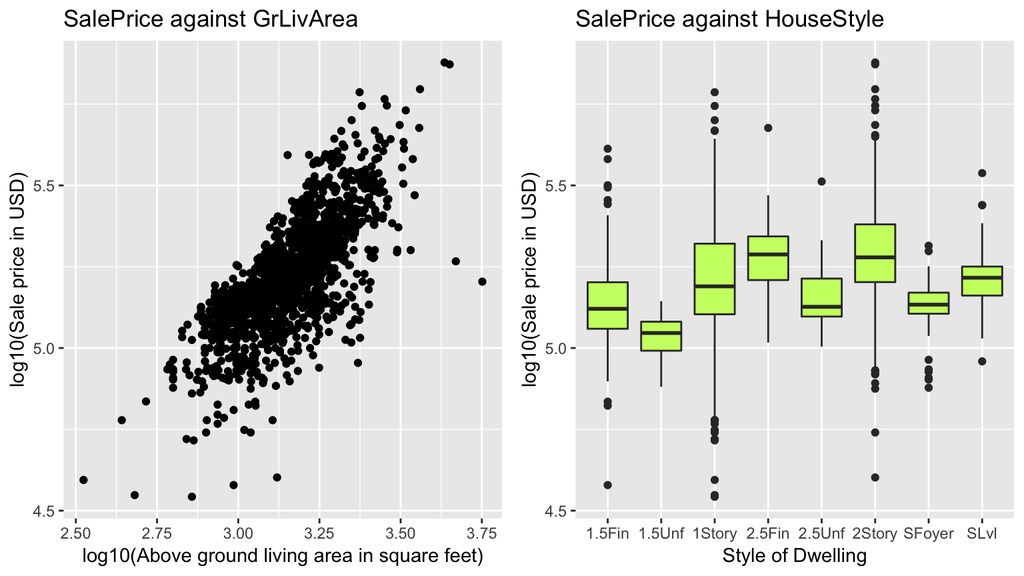

```r
require(gridExtra)
grid.arrange(plot1, plot2, ncol=2)
```

For instance, we can determine that there is a relatively strong positive relationship between the outcome variable, SalePrice, and the numerical predictor variable, GrLivArea, from the scatterplot above. Similarly, we can deduce from the boxplots that houses with two and one-half stories (where the 2nd level of the house is finished) have higher sale prices compared to other styles of dwelling.

# Minimally viable product

## Model fitting

```r
# MINIMALLY VIABLE PRODUCT
# 1. Fit model to training data
model_1_formula <- as.formula("log10_SalePrice ~ log10_GrLivArea + HouseStyle")
model_1 <- lm(model_1_formula, data = training)
# Fit MVP model on actual test data and submit to Kaggle
predicted_points <- model_1 %>%
  broom::augment(newdata = test)
test <- test %>%
  mutate(log10_SalePrice_hat = predicted_points$.fitted,
        SalePrice_hat = 10^log10_SalePrice_hat)
```

## Create your submission CSV

```r
submission <- test %>%
  mutate(SalePrice = SalePrice_hat) %>%
  select(Id, SalePrice)
write.csv(submission, "data/submission_mvp.csv", row.names = F)
```

# Due diligence

Obtain an estimate $\widehat{RMLSE}$ that closely matches the RMLSE that Kaggle returns.

```r
# Calculate RMLSE for MVP model with one numeric and one categorical predictor - 0.2564427
training <- training %>%
  sample_frac(1) %>%
  mutate(fold = rep(1:5, length = n())) %>%
  arrange(fold)

RMLSE <- rep(0, 5)

for(j in 1:5) {
  pretend_training <- training %>%
    filter(fold != j)
  pretend_test <- training %>%
    filter(fold == j)

  # Fit model on pretend training
  model_1_formula <- as.formula("log10_SalePrice ~ log10_GrLivArea + HouseStyle")
  model_1 <- lm(model_1_formula, data = pretend_training)

  # Make predictions on pretend test data.
  predicted_points_1 <- model_1 %>%
    broom::augment(newdata = pretend_test)

  # Save predictions in pretend_test data frame
  pretend_test <- pretend_test %>%
    mutate(log10_SalePrice_hat = predicted_points_1$.fitted,
           SalePrice_hat = 10^log10_SalePrice_hat)

  RMLSE[j] <- pretend_test %>%
    mutate(
      residual = log(SalePrice + 1) - log(SalePrice_hat + 1),
      residual_sq = residual^2
    ) %>%
    summarize(
      MLSE = mean(residual_sq),
      RMLSE = sqrt(MLSE)
    ) %>%
    pull(RMLSE)
}

RMLSE_hat <- mean(RMLSE)
RMLSE_hat
```

```
## [1] 0.2415548
```

The estimated RMLSE from the 5-fold CV is 0.24155 as compared to the actual Kaggle score of 0.253. These are very close!